# Codebook for data_processed

Autogenerated data summary from dataMaid

2024-01-10 15:52:44.79404

# Data report overview

The dataset examined has the following dimensions:

| Feature | Result |
| --- | --- |
| Number of observations | 179 |
| Number of variables | 61 |

# Codebook summary table

[output not shown]

# Variable list

## id

- The variable is a key (distinct values for each observation).

## age

| Feature | Result |
| --- | --- |
| Variable type | character |
| Number of missing obs. | 26 (14.53 %) |
| Number of unique values | 41 |
| Mode | “21” |

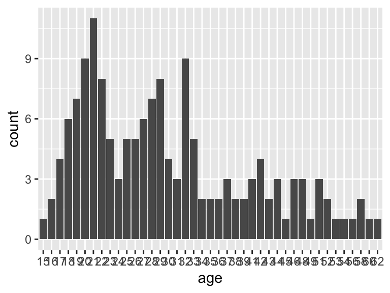

- Observed factor levels: "15", "16", "17", "18", "19", "20", "21", "22", "23", "24", "25", "26", "27", "28", "29", "30", "31", "32", "33", "34", "35", "36", "37", "38", "39", "41", "42", "43", "44", "45", "46", "48", "49", "51", "52", "53", "54", "56", "58", "60", "62".

## sex

| Feature | Result |
| --- | --- |
| Variable type | character |
| Number of missing obs. | 26 (14.53 %) |
| Number of unique values | 2 |
| Mode | “f” |

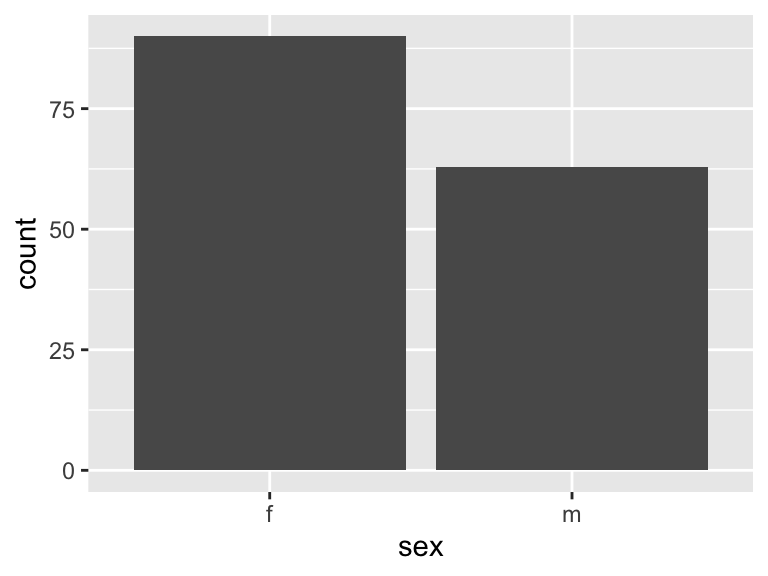

- Observed factor levels: "f", "m".

## bfi_a1

| Feature | Result |
| --- | --- |
| Variable type | numeric |
| Number of missing obs. | 79 (44.13 %) |
| Number of unique values | 6 |
| Median | 3 |
| 1st and 3rd quartiles | 2; 5 |
| Min. and max. | 1; 6 |

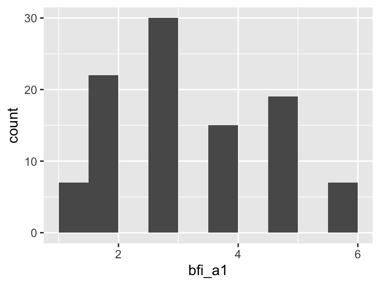

## bfi_a2

| Feature | Result |
| --- | --- |
| Variable type | numeric |
| Number of missing obs. | 81 (45.25 %) |
| Number of unique values | 5 |
| Median | 5 |
| 1st and 3rd quartiles | 4; 5.75 |
| Min. and max. | 2; 6 |

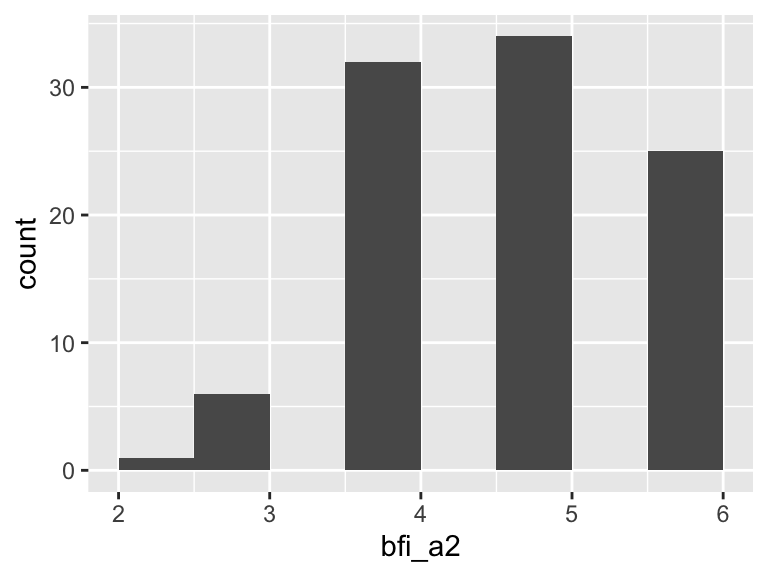

## bfi_a3

| Feature | Result |
| --- | --- |
| Variable type | numeric |
| Number of missing obs. | 79 (44.13 %) |
| Number of unique values | 7 |
| Median | 5 |
| 1st and 3rd quartiles | 4; 6 |
| Min. and max. | 1; 7 |

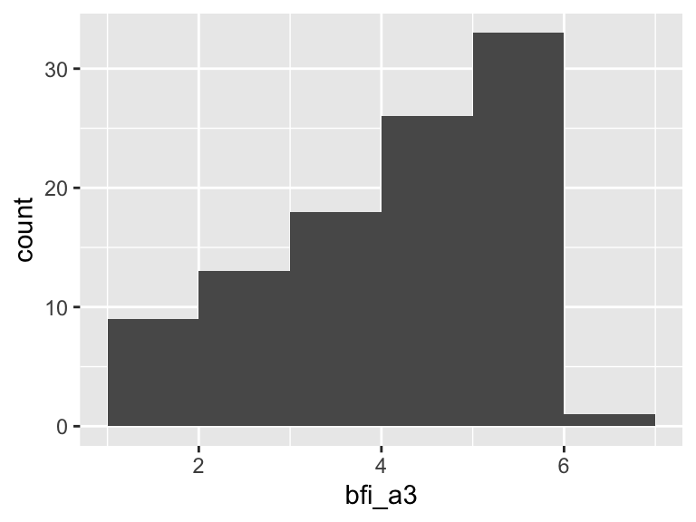

## bfi_a4

| Feature | Result |
| --- | --- |
| Variable type | numeric |
| Number of missing obs. | 79 (44.13 %) |
| Number of unique values | 6 |
| Median | 5 |
| 1st and 3rd quartiles | 4; 6 |
| Min. and max. | 1; 6 |

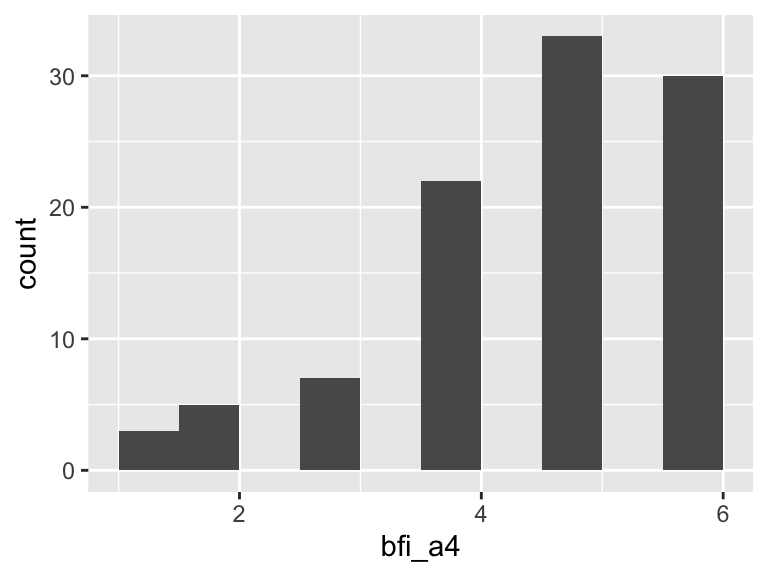

## bfi_a5

| Feature | Result |
| --- | --- |
| Variable type | numeric |
| Number of missing obs. | 79 (44.13 %) |
| Number of unique values | 7 |
| Median | 5 |
| 1st and 3rd quartiles | 4; 6 |
| Min. and max. | 0; 6 |

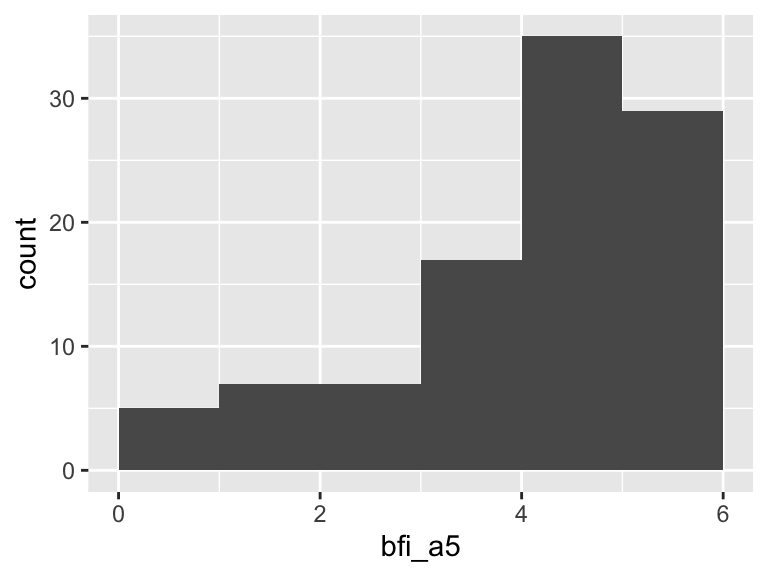

## bfi_a6

| Feature | Result |
| --- | --- |
| Variable type | numeric |
| Number of missing obs. | 80 (44.69 %) |
| Number of unique values | 6 |
| Median | 4 |
| 1st and 3rd quartiles | 3; 5 |
| Min. and max. | 1; 6 |

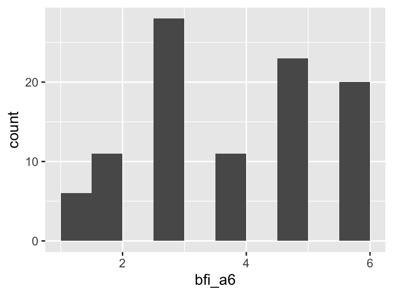

## bfi_a7

| Feature | Result |
| --- | --- |
| Variable type | numeric |
| Number of missing obs. | 79 (44.13 %) |
| Number of unique values | 6 |
| Median | 5 |
| 1st and 3rd quartiles | 4; 6 |
| Min. and max. | 1; 6 |

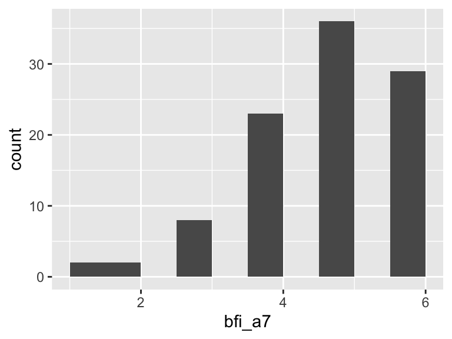

## bfi_a8

| Feature | Result |
| --- | --- |
| Variable type | numeric |
| Number of missing obs. | 79 (44.13 %) |
| Number of unique values | 6 |
| Median | 4 |
| 1st and 3rd quartiles | 3; 5 |
| Min. and max. | 1; 6 |

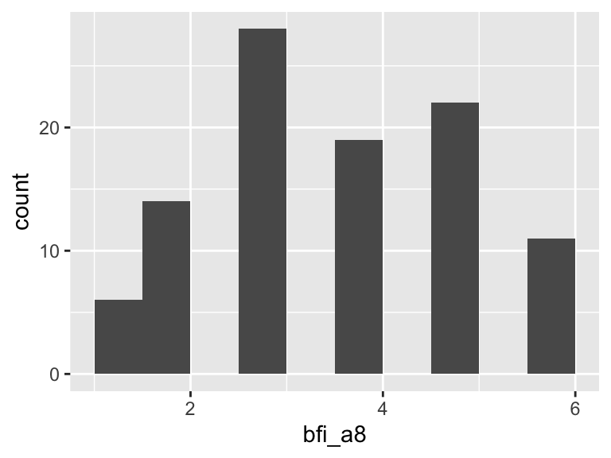

## bfi_a9

| Feature | Result |
| --- | --- |
| Variable type | numeric |
| Number of missing obs. | 79 (44.13 %) |
| Number of unique values | 5 |
| Median | 5 |
| 1st and 3rd quartiles | 4; 6 |
| Min. and max. | 2; 6 |

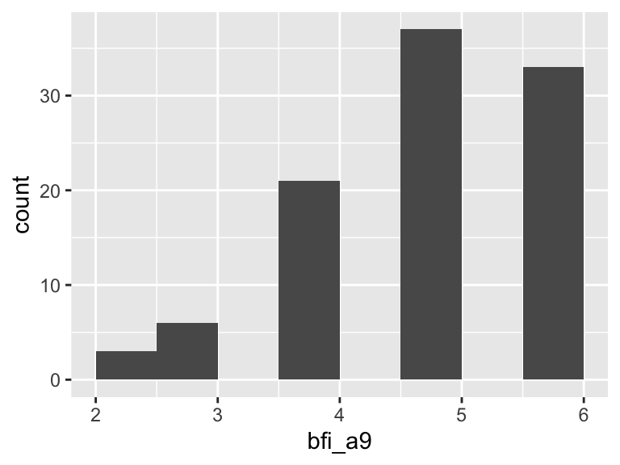

## bfi_c1

| Feature | Result |
| --- | --- |
| Variable type | numeric |
| Number of missing obs. | 100 (55.87 %) |
| Number of unique values | 5 |
| Median | 5 |
| 1st and 3rd quartiles | 5; 6 |
| Min. and max. | 2; 6 |

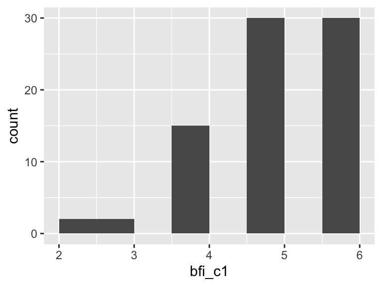

## bfi_c2

| Feature | Result |
| --- | --- |
| Variable type | numeric |
| Number of missing obs. | 100 (55.87 %) |
| Number of unique values | 6 |
| Median | 4 |
| 1st and 3rd quartiles | 3; 5 |
| Min. and max. | 1; 6 |

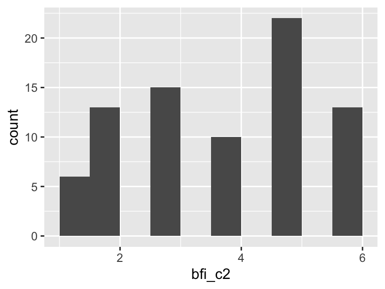

## bfi_c3

| Feature | Result |
| --- | --- |
| Variable type | numeric |
| Number of missing obs. | 100 (55.87 %) |
| Number of unique values | 6 |
| Median | 6 |
| 1st and 3rd quartiles | 5; 6 |
| Min. and max. | 2; 7 |

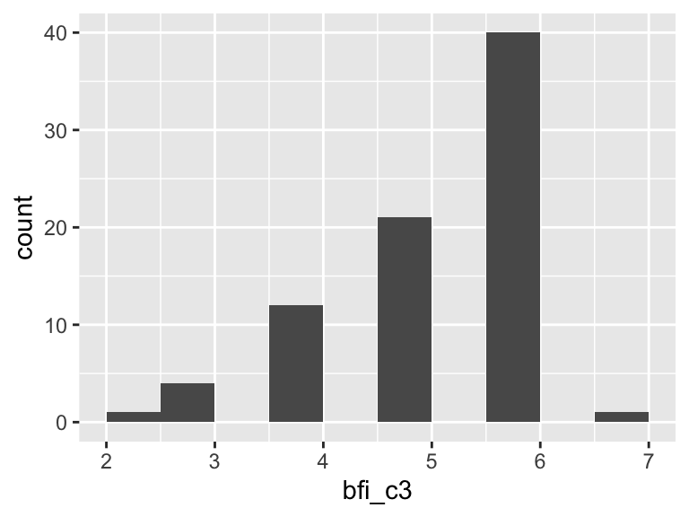

## bfi_c4

| Feature | Result |
| --- | --- |
| Variable type | numeric |
| Number of missing obs. | 100 (55.87 %) |
| Number of unique values | 6 |
| Median | 3 |
| 1st and 3rd quartiles | 2.5; 5 |
| Min. and max. | 1; 6 |

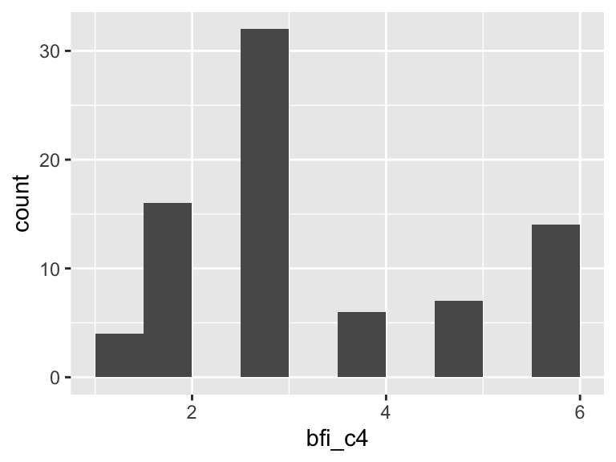

## bfi_c5

| Feature | Result |
| --- | --- |
| Variable type | numeric |
| Number of missing obs. | 100 (55.87 %) |
| Number of unique values | 6 |
| Median | 4 |
| 1st and 3rd quartiles | 3; 5 |
| Min. and max. | 1; 6 |

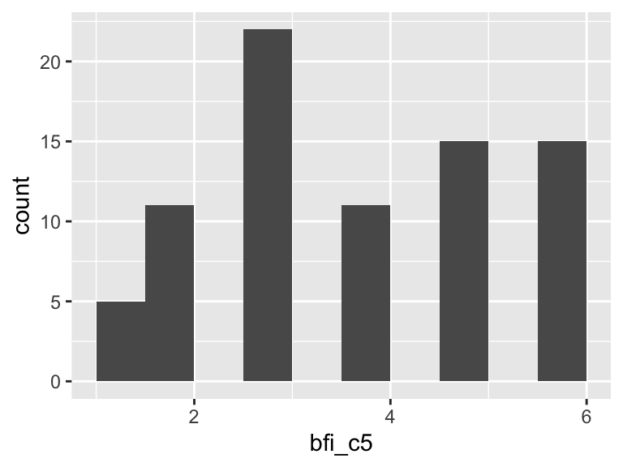

## bfi_c6

| Feature | Result |
| --- | --- |
| Variable type | numeric |
| Number of missing obs. | 100 (55.87 %) |
| Number of unique values | 6 |
| Median | 5 |
| 1st and 3rd quartiles | 4; 6 |
| Min. and max. | 1; 6 |

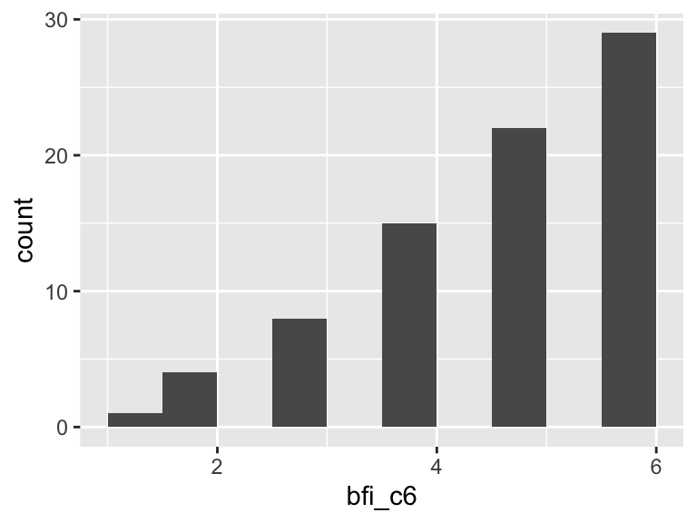

## bfi_c7

| Feature | Result |
| --- | --- |
| Variable type | numeric |
| Number of missing obs. | 101 (56.42 %) |
| Number of unique values | 6 |
| Median | 5 |
| 1st and 3rd quartiles | 4; 5 |
| Min. and max. | 1; 6 |

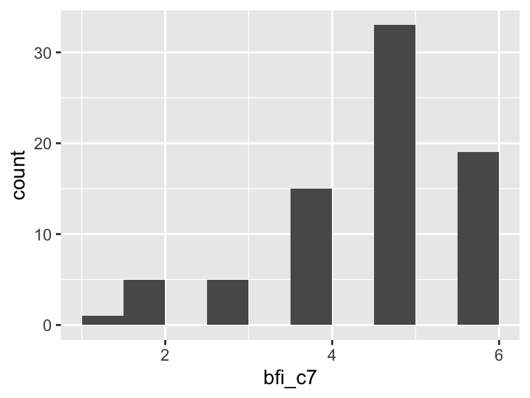

## bfi_c8

| Feature | Result |
| --- | --- |
| Variable type | numeric |
| Number of missing obs. | 100 (55.87 %) |
| Number of unique values | 5 |
| Median | 5 |
| 1st and 3rd quartiles | 4; 6 |
| Min. and max. | 2; 6 |

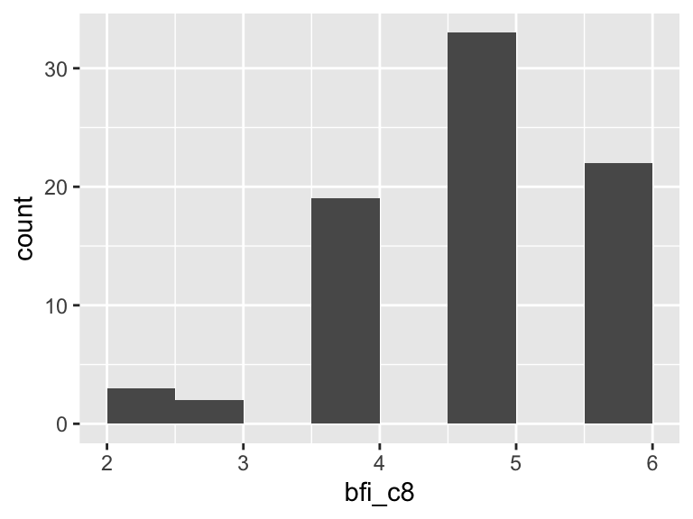

## bfi_c9

| Feature | Result |
| --- | --- |
| Variable type | numeric |
| Number of missing obs. | 101 (56.42 %) |
| Number of unique values | 6 |
| Median | 3 |
| 1st and 3rd quartiles | 2; 4.75 |
| Min. and max. | 1; 6 |

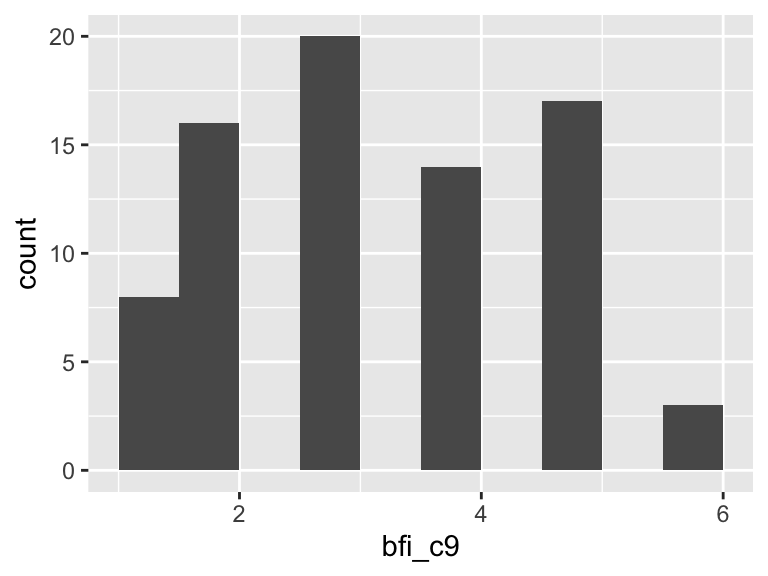

## bfi_e1

| Feature | Result |
| --- | --- |
| Variable type | numeric |
| Number of missing obs. | 100 (55.87 %) |
| Number of unique values | 6 |
| Median | 4 |
| 1st and 3rd quartiles | 3; 5.5 |
| Min. and max. | 1; 6 |

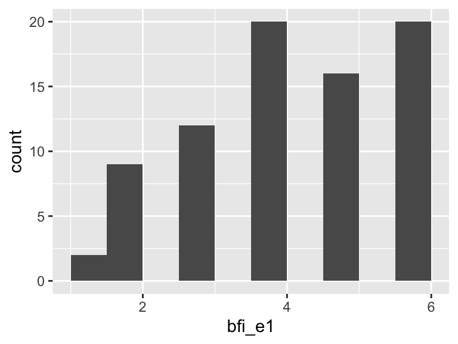

## bfi_e2

| Feature | Result |
| --- | --- |
| Variable type | numeric |
| Number of missing obs. | 100 (55.87 %) |
| Number of unique values | 6 |
| Median | 3 |
| 1st and 3rd quartiles | 2; 4 |
| Min. and max. | 1; 6 |

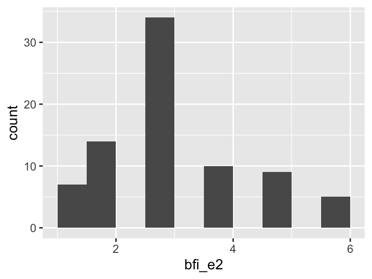

## bfi_e3

| Feature | Result |
| --- | --- |
| Variable type | numeric |
| Number of missing obs. | 100 (55.87 %) |
| Number of unique values | 6 |
| Median | 4 |
| 1st and 3rd quartiles | 3; 5 |
| Min. and max. | 1; 6 |

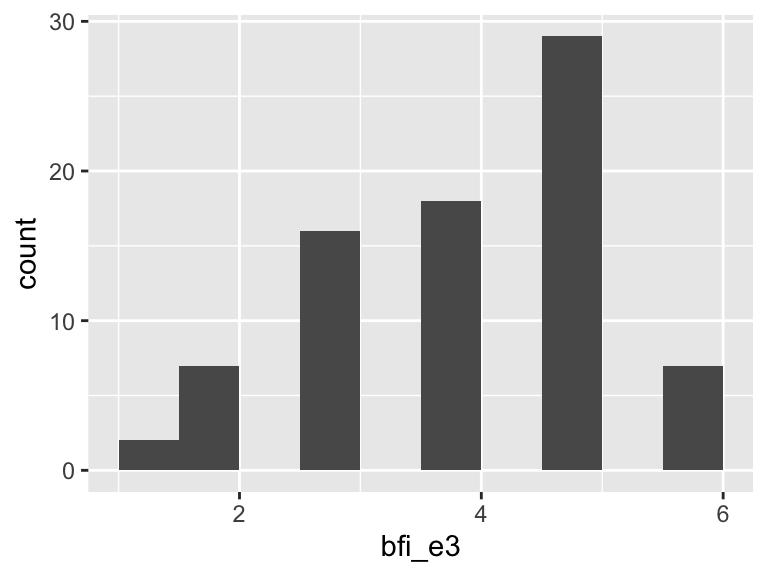

## bfi_e4

| Feature | Result |
| --- | --- |
| Variable type | numeric |
| Number of missing obs. | 101 (56.42 %) |
| Number of unique values | 7 |
| Median | 5 |
| 1st and 3rd quartiles | 4; 5 |
| Min. and max. | 1; 7 |

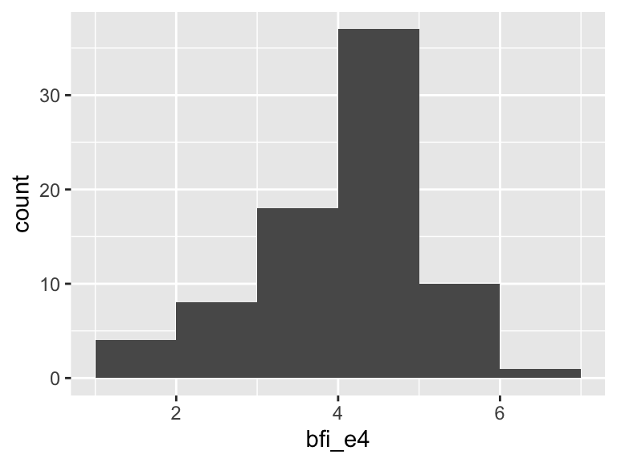

## bfi_e5

| Feature | Result |
| --- | --- |
| Variable type | numeric |
| Number of missing obs. | 100 (55.87 %) |
| Number of unique values | 6 |
| Median | 3 |
| 1st and 3rd quartiles | 2; 4 |
| Min. and max. | 1; 6 |

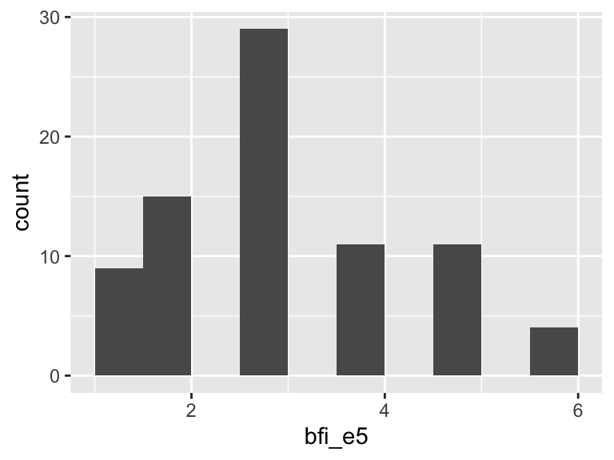

## bfi_e6

| Feature | Result |
| --- | --- |
| Variable type | numeric |
| Number of missing obs. | 100 (55.87 %) |
| Number of unique values | 6 |
| Median | 5 |
| 1st and 3rd quartiles | 4; 5 |
| Min. and max. | 1; 6 |

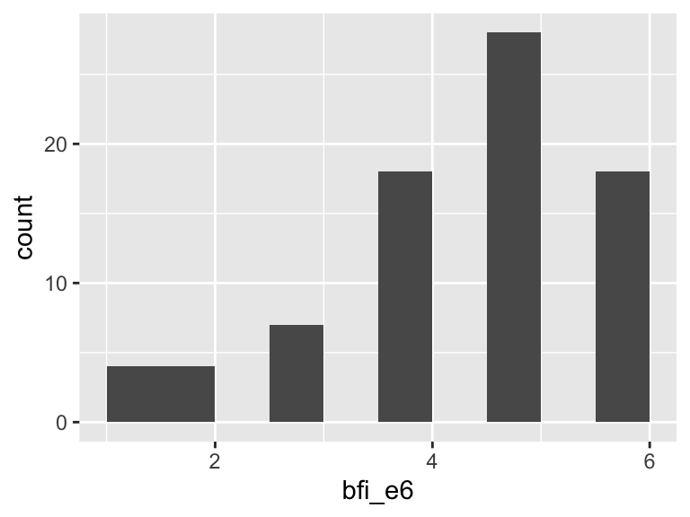

## bfi_e7

| Feature | Result |
| --- | --- |
| Variable type | numeric |
| Number of missing obs. | 100 (55.87 %) |
| Number of unique values | 6 |
| Median | 3 |
| 1st and 3rd quartiles | 2; 3 |
| Min. and max. | 1; 6 |

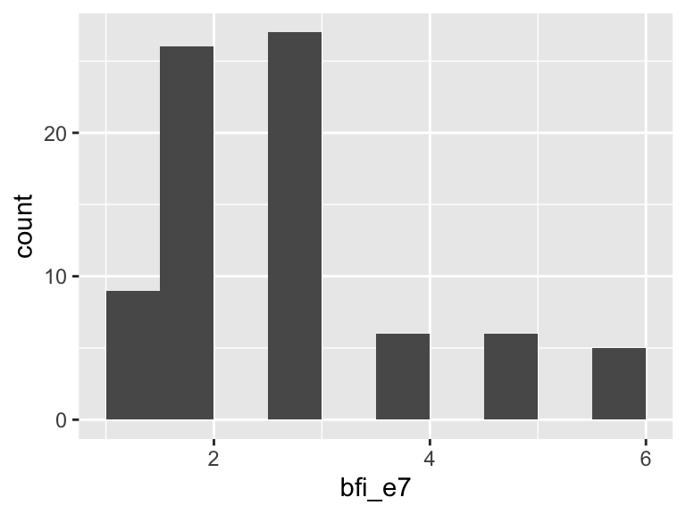

## bfi_e8

| Feature | Result |
| --- | --- |
| Variable type | numeric |
| Number of missing obs. | 100 (55.87 %) |
| Number of unique values | 6 |
| Median | 5 |
| 1st and 3rd quartiles | 3.5; 5 |
| Min. and max. | 1; 6 |

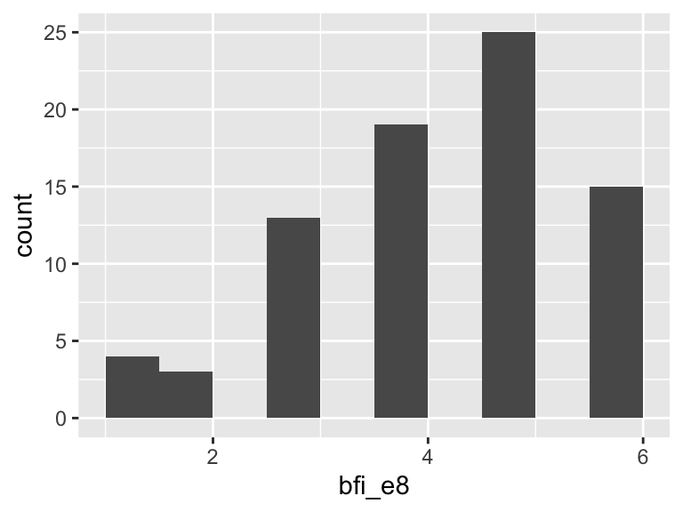

## bfi_n1

| Feature | Result |
| --- | --- |
| Variable type | numeric |
| Number of missing obs. | 100 (55.87 %) |
| Number of unique values | 6 |
| Median | 2 |
| 1st and 3rd quartiles | 2; 4 |
| Min. and max. | 1; 6 |

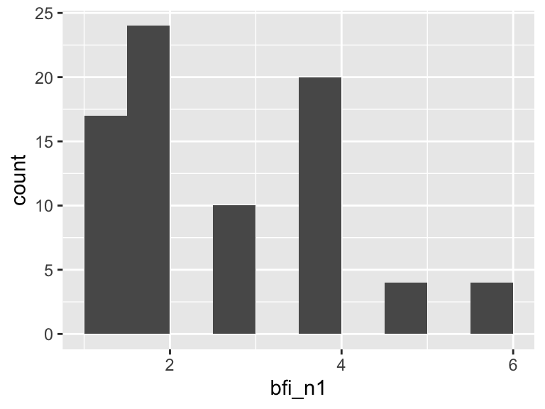

## bfi_n2

| Feature | Result |
| --- | --- |
| Variable type | numeric |
| Number of missing obs. | 100 (55.87 %) |
| Number of unique values | 6 |
| Median | 3 |
| 1st and 3rd quartiles | 2; 3 |
| Min. and max. | 1; 6 |

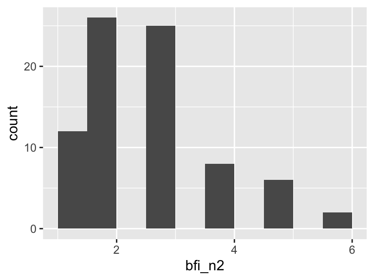

## bfi_n3

| Feature | Result |
| --- | --- |
| Variable type | numeric |
| Number of missing obs. | 100 (55.87 %) |
| Number of unique values | 6 |
| Median | 4 |
| 1st and 3rd quartiles | 4; 5 |
| Min. and max. | 1; 6 |

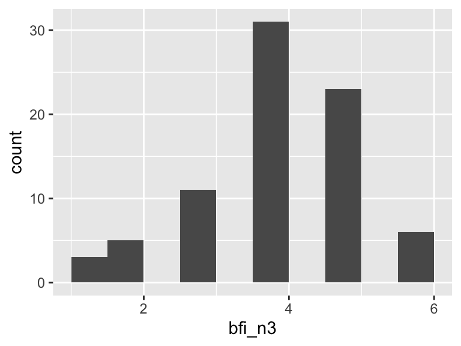

## bfi_n4

| Feature | Result |
| --- | --- |
| Variable type | numeric |
| Number of missing obs. | 100 (55.87 %) |
| Number of unique values | 6 |
| Median | 4 |
| 1st and 3rd quartiles | 2; 5 |
| Min. and max. | 1; 6 |

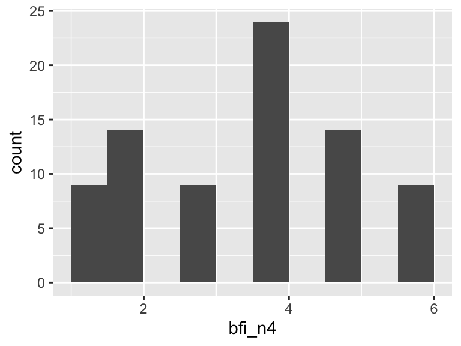

## bfi_n5

| Feature | Result |
| --- | --- |
| Variable type | numeric |
| Number of missing obs. | 100 (55.87 %) |
| Number of unique values | 6 |
| Median | 2 |
| 1st and 3rd quartiles | 1; 3 |
| Min. and max. | 1; 6 |

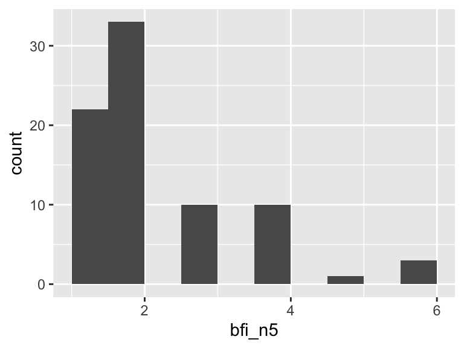

## bfi_n6

| Feature | Result |
| --- | --- |
| Variable type | numeric |
| Number of missing obs. | 100 (55.87 %) |
| Number of unique values | 6 |
| Median | 4 |
| 1st and 3rd quartiles | 3; 5 |
| Min. and max. | 1; 6 |

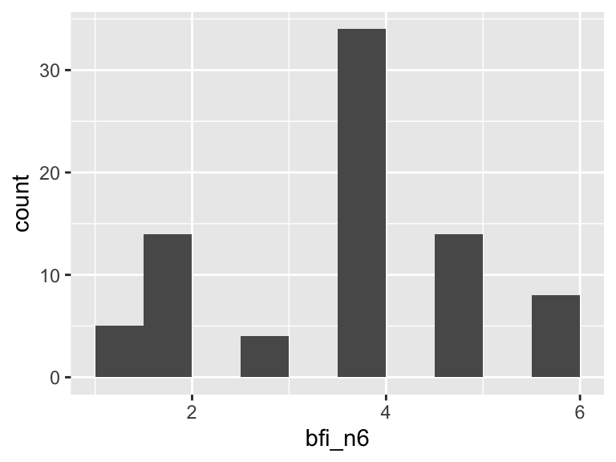

## bfi_n7

| Feature | Result |
| --- | --- |
| Variable type | numeric |
| Number of missing obs. | 100 (55.87 %) |
| Number of unique values | 6 |
| Median | 2 |
| 1st and 3rd quartiles | 1; 3 |
| Min. and max. | 1; 6 |

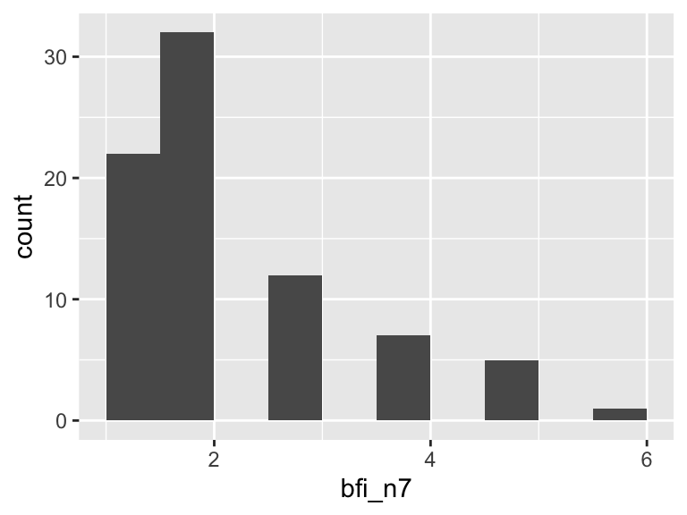

## bfi_n8

| Feature | Result |
| --- | --- |
| Variable type | numeric |
| Number of missing obs. | 100 (55.87 %) |
| Number of unique values | 6 |
| Median | 4 |
| 1st and 3rd quartiles | 2; 4 |
| Min. and max. | 1; 6 |

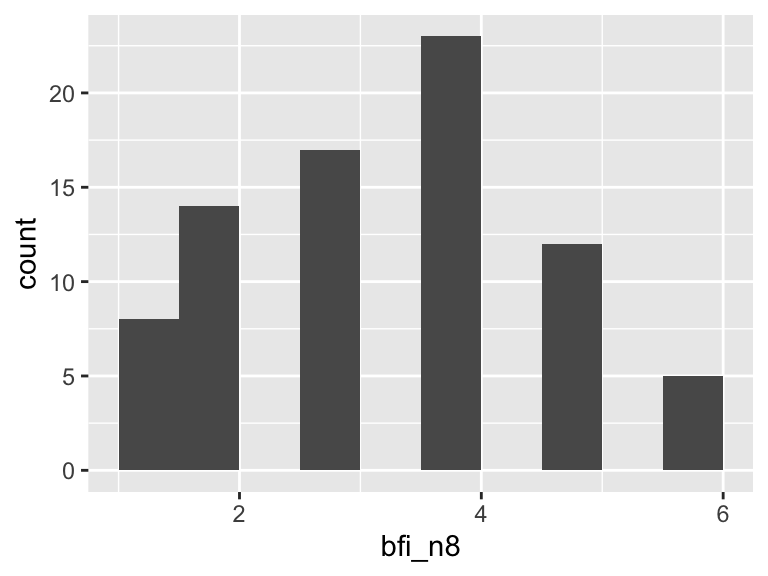

## bfi_o1

| Feature | Result |
| --- | --- |
| Variable type | numeric |
| Number of missing obs. | 79 (44.13 %) |
| Number of unique values | 6 |
| Median | 5 |
| 1st and 3rd quartiles | 4; 5 |
| Min. and max. | 1; 6 |

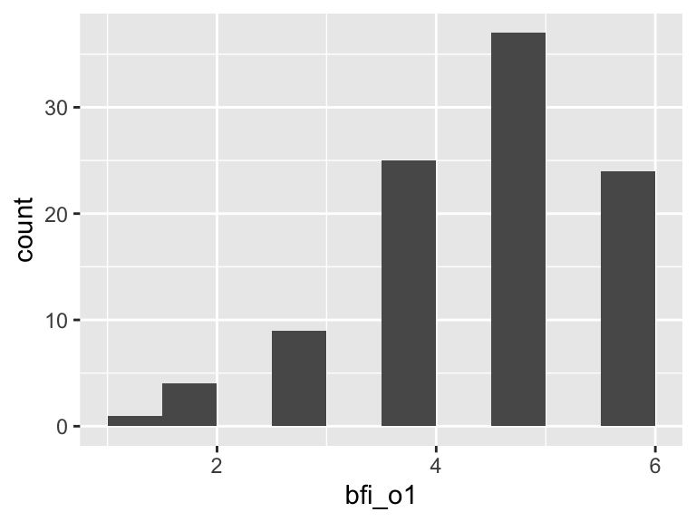

## bfi_o10

| Feature | Result |
| --- | --- |
| Variable type | numeric |
| Number of missing obs. | 79 (44.13 %) |
| Number of unique values | 7 |
| Median | 4 |
| 1st and 3rd quartiles | 3; 5 |
| Min. and max. | 0; 6 |

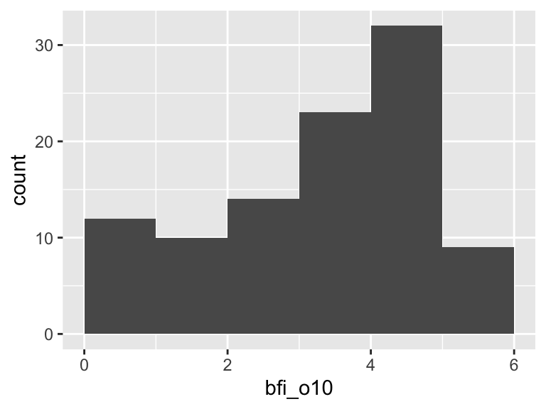

## bfi_o2

| Feature | Result |
| --- | --- |
| Variable type | numeric |
| Number of missing obs. | 79 (44.13 %) |
| Number of unique values | 7 |
| Median | 6 |
| 1st and 3rd quartiles | 5; 6 |
| Min. and max. | 0; 6 |

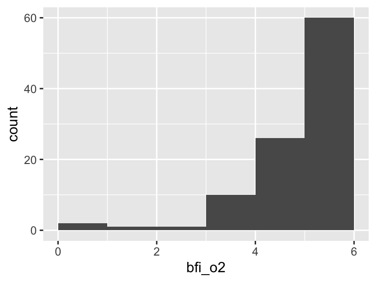

## bfi_o3

| Feature | Result |
| --- | --- |
| Variable type | numeric |
| Number of missing obs. | 79 (44.13 %) |
| Number of unique values | 6 |
| Median | 5 |
| 1st and 3rd quartiles | 4; 5 |
| Min. and max. | 1; 6 |

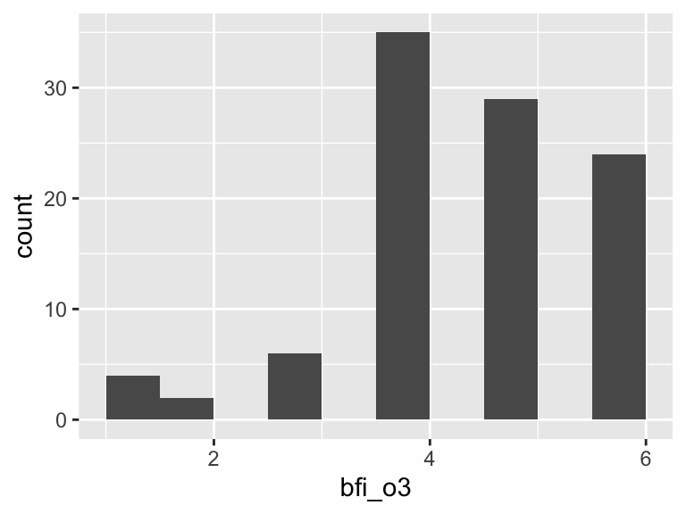

## bfi_o4

| Feature | Result |
| --- | --- |
| Variable type | numeric |
| Number of missing obs. | 79 (44.13 %) |
| Number of unique values | 6 |
| Median | 5 |
| 1st and 3rd quartiles | 4; 6 |
| Min. and max. | 1; 6 |

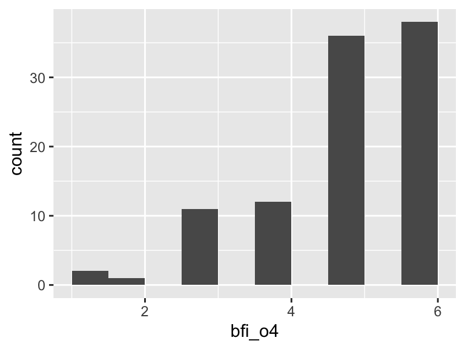

## bfi_o5

| Feature | Result |
| --- | --- |
| Variable type | numeric |
| Number of missing obs. | 79 (44.13 %) |
| Number of unique values | 7 |
| Median | 5 |
| 1st and 3rd quartiles | 4; 5 |
| Min. and max. | 1; 7 |

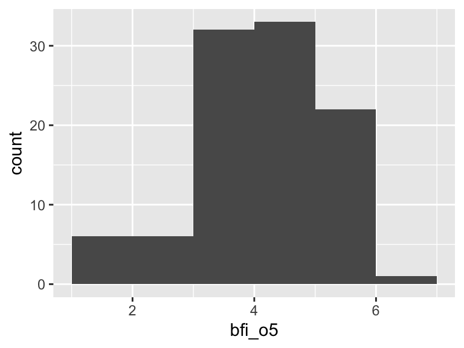

## bfi_o6

| Feature | Result |
| --- | --- |
| Variable type | numeric |
| Number of missing obs. | 79 (44.13 %) |
| Number of unique values | 6 |
| Median | 5 |
| 1st and 3rd quartiles | 4; 6 |
| Min. and max. | 1; 6 |

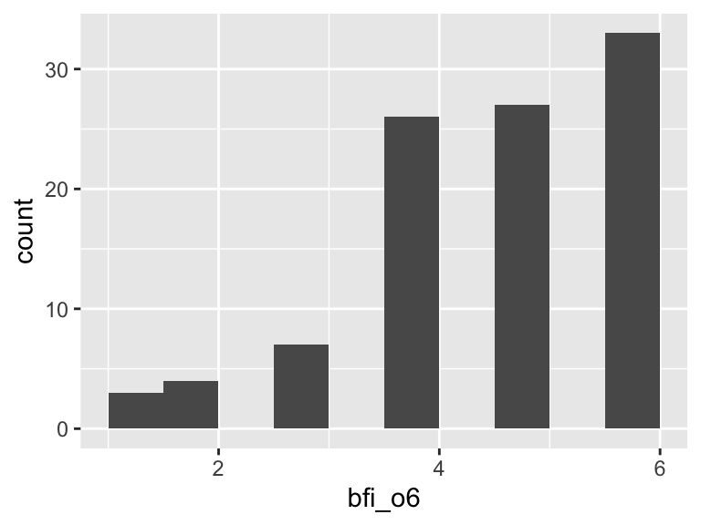

## bfi_o7

| Feature | Result |
| --- | --- |
| Variable type | numeric |
| Number of missing obs. | 80 (44.69 %) |
| Number of unique values | 6 |
| Median | 4 |
| 1st and 3rd quartiles | 3; 5 |
| Min. and max. | 1; 6 |

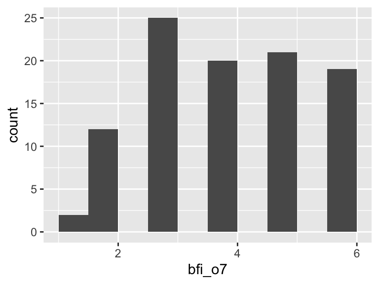

## bfi_o8

| Feature | Result |
| --- | --- |
| Variable type | numeric |
| Number of missing obs. | 80 (44.69 %) |
| Number of unique values | 6 |
| Median | 5 |
| 1st and 3rd quartiles | 4; 6 |
| Min. and max. | 2; 7 |

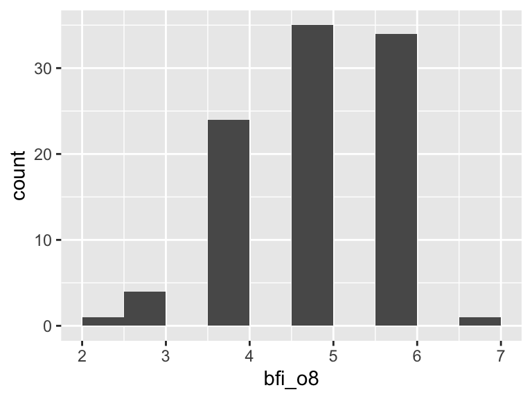

## bfi_o9

| Feature | Result |
| --- | --- |
| Variable type | numeric |
| Number of missing obs. | 81 (45.25 %) |
| Number of unique values | 7 |
| Median | 5 |
| 1st and 3rd quartiles | 3; 5.75 |
| Min. and max. | 1; 7 |

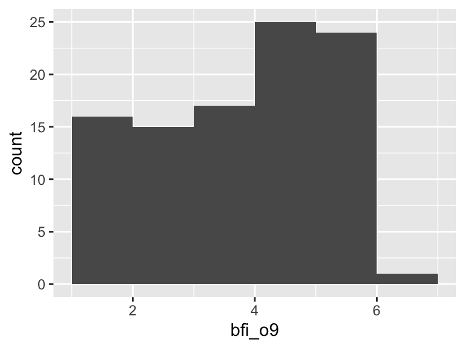

## mean_agreeableness

| Feature | Result |
| --- | --- |
| Variable type | numeric |
| Number of missing obs. | 79 (44.13 %) |
| Number of unique values | 34 |
| Median | 4.33 |
| 1st and 3rd quartiles | 3.89; 4.92 |
| Min. and max. | 2.33; 5.89 |

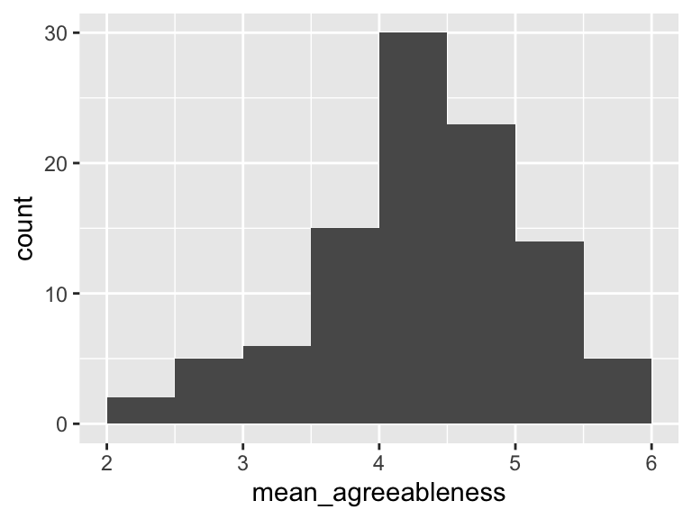

## mean_conscientiousness

| Feature | Result |
| --- | --- |
| Variable type | numeric |
| Number of missing obs. | 100 (55.87 %) |
| Number of unique values | 29 |
| Median | 4.33 |
| 1st and 3rd quartiles | 3.72; 5 |
| Min. and max. | 2.33; 5.89 |

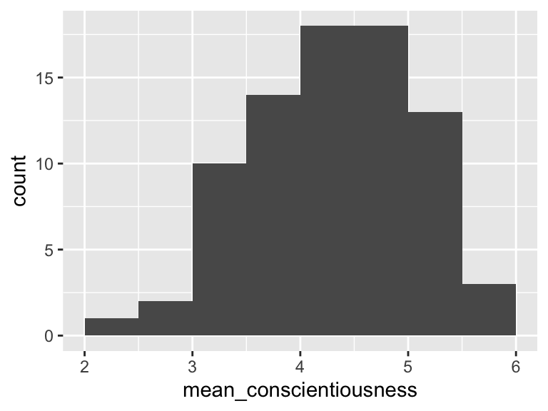

## mean_extraversion

| Feature | Result |
| --- | --- |
| Variable type | numeric |
| Number of missing obs. | 100 (55.87 %) |
| Number of unique values | 28 |
| Median | 3.88 |
| 1st and 3rd quartiles | 3.38; 4.38 |
| Min. and max. | 1.88; 5.62 |

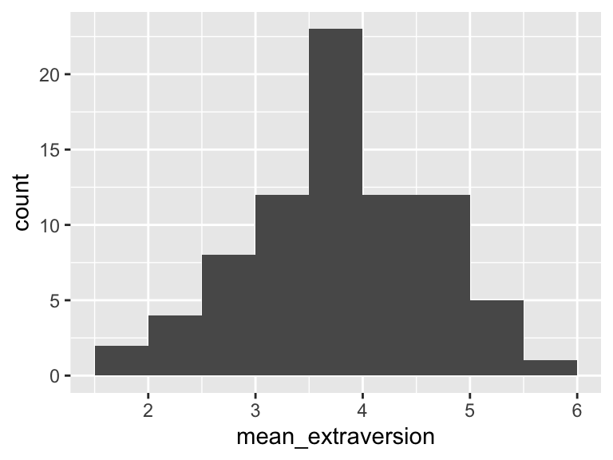

## mean_neuroticism

| Feature | Result |
| --- | --- |
| Variable type | numeric |
| Number of missing obs. | 100 (55.87 %) |
| Number of unique values | 28 |
| Median | 3 |
| 1st and 3rd quartiles | 2.5; 3.69 |
| Min. and max. | 1.25; 5.62 |

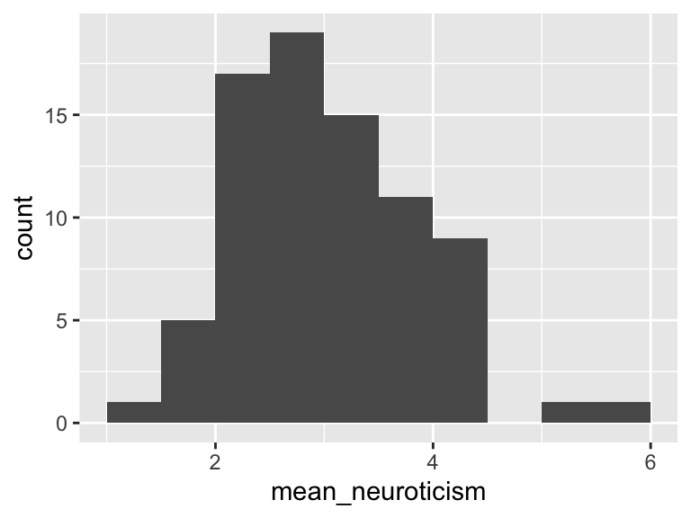

## mean_openness

| Feature | Result |
| --- | --- |
| Variable type | numeric |
| Number of missing obs. | 79 (44.13 %) |
| Number of unique values | 34 |
| Median | 4.6 |
| 1st and 3rd quartiles | 4.2; 5.1 |
| Min. and max. | 2.3; 6 |

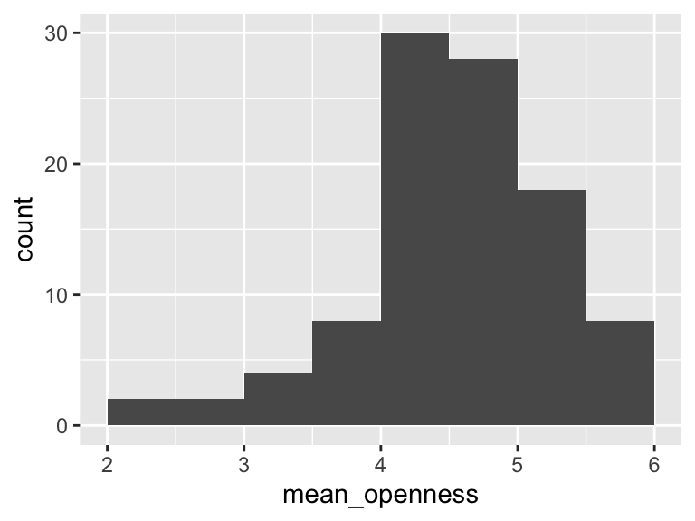

## exclusion_bfi_completion

- The variable only takes one (non-missing) value: "include". The variable contains 0 % missing observations.

## exclusion_bfi_score

| Feature | Result |
| --- | --- |
| Variable type | character |
| Number of missing obs. | 0 (0 %) |
| Number of unique values | 2 |
| Mode | “include” |

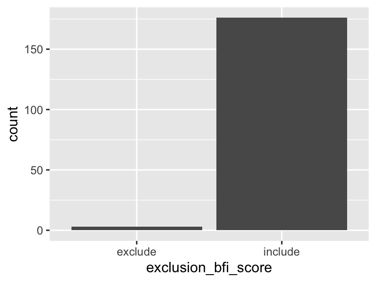

- Observed factor levels: "exclude", "include".

## iat_mean1

| Feature | Result |
| --- | --- |
| Variable type | numeric |
| Number of missing obs. | 0 (0 %) |
| Number of unique values | 179 |
| Median | 836.12 |
| 1st and 3rd quartiles | 714.49; 1046.23 |
| Min. and max. | 500.8; 4908.1 |

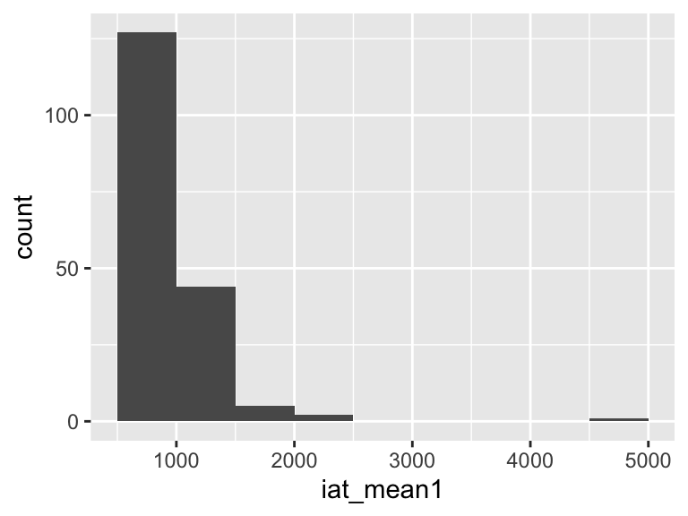

## iat_mean2

| Feature | Result |
| --- | --- |
| Variable type | numeric |
| Number of missing obs. | 0 (0 %) |
| Number of unique values | 179 |
| Median | 745.72 |
| 1st and 3rd quartiles | 666.66; 855.87 |
| Min. and max. | 408.46; 2793.9 |

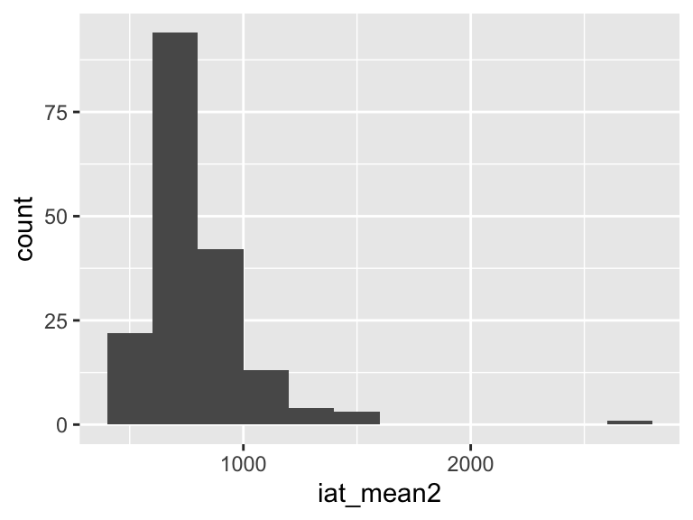

## iat_sd

| Feature | Result |
| --- | --- |
| Variable type | numeric |
| Number of missing obs. | 0 (0 %) |
| Number of unique values | 179 |
| Median | 353.36 |
| 1st and 3rd quartiles | 247.75; 481.45 |
| Min. and max. | 115.84; 3781.56 |

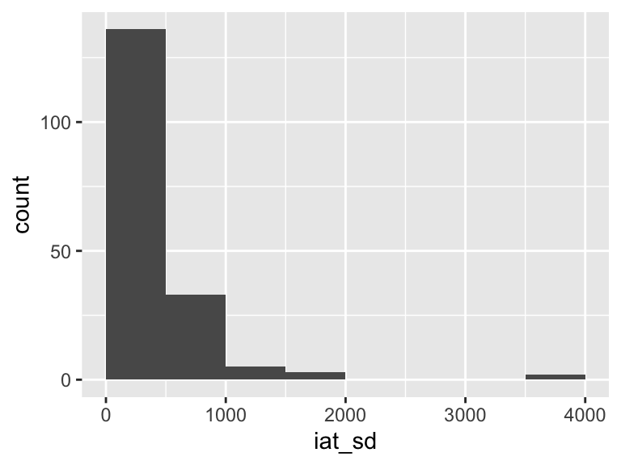

## iat_D_score

| Feature | Result |
| --- | --- |
| Variable type | numeric |
| Number of missing obs. | 0 (0 %) |
| Number of unique values | 179 |
| Median | -0.28 |
| 1st and 3rd quartiles | -0.5; -0.05 |
| Min. and max. | -0.95; 0.34 |

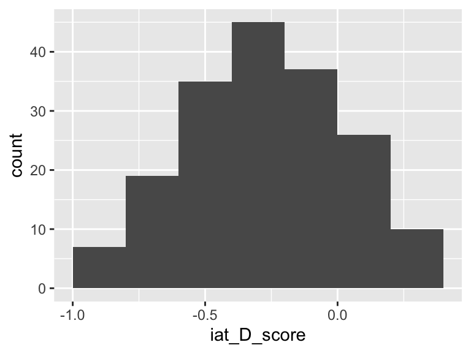

## exclusion_iat_completion

| Feature | Result |
| --- | --- |
| Variable type | character |
| Number of missing obs. | 0 (0 %) |
| Number of unique values | 2 |
| Mode | “include” |

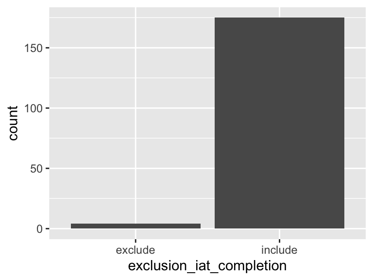

- Observed factor levels: "exclude", "include".

## exclusion_iat_performance

| Feature | Result |
| --- | --- |
| Variable type | character |
| Number of missing obs. | 0 (0 %) |
| Number of unique values | 2 |
| Mode | “include” |

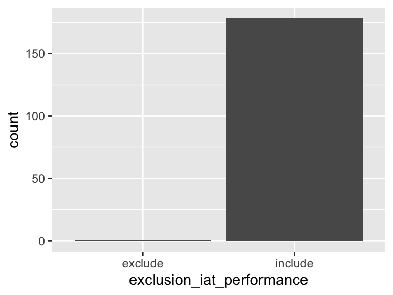

- Observed factor levels: "exclude", "include".

## exclude_participant

| Feature | Result |
| --- | --- |
| Variable type | character |
| Number of missing obs. | 0 (0 %) |
| Number of unique values | 2 |
| Mode | “include” |

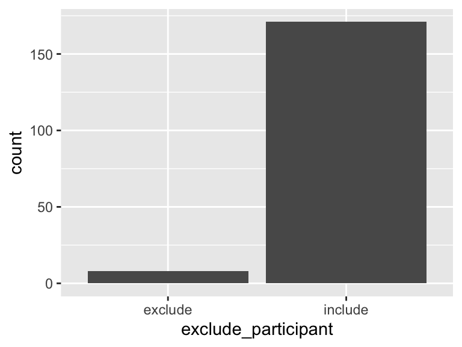

- Observed factor levels: "exclude", "include".

Report generation information:

- Created by: Isabel Mayer (username: `Isa`).
- Report creation time: Wed Jan 10 2024 15:52:44
- Report was run from directory: `/Users/Isa/Documents/Uni/Master/HS23/Methodenseminar/GitHub2.0/dpm-assignments/week 12 (final assignment)/personality and race-IAT study/code`
- dataMaid v1.4.1 [Pkg: 2021-10-08 from CRAN (R 4.3.0)]
- R version 4.3.1 (2023-06-16).
- Platform: aarch64-apple-darwin20 (64-bit)(Europe/Berlin).
- Function call: `dataMaid::makeDataReport(data = data_processed, mode = c("summarize", "visualize", "check"), smartNum = FALSE, file = "codebook_data_processed.Rmd", replace = TRUE, checks = list(character = "showAllFactorLevels", factor = "showAllFactorLevels", labelled = "showAllFactorLevels", haven_labelled = "showAllFactorLevels", numeric = NULL, integer = NULL, logical = NULL, Date = NULL), listChecks = FALSE, maxProbVals = Inf, codebook = TRUE, reportTitle = "Codebook for data_processed")`